# Replicating Abadie et al. (2010) with the `augsynth` package

Delaney & Miratrix

2024-11-16

This vignette replicates the analysis and figures in [Abadie et al. (2010)](https://web.stanford.edu/~jhain/Paper/JASA2010.pdf) using the `augsynth` package. In particular, our recent extensions to the `augsynth` package streamline permutation-based inference and associated visualizations on behalf of the user. In the following, we show how to easily generate results similar (but not entirely identical) to Figures 2-7 in the original paper.

While the general intuition of Abadie et al.’s analysis is replicated in the `augsynth` package, it is worth noting that covariates and model parameters are handled somewhat differently than in the original analysis. In particular, unlike the `augsynth` package, the `Synth` package used in Abadie et al.’s analysis reweights a subset of the lagged outcomes and passed auxiliary covariates when generating synthetic weights. The `augsynth` package, by contrast, directly balances *all* pre-treatment outcomes along with auxillary covariates, which means it does not dynamically determine variable importance weights.

In this vignette we also include `Synth` code to generate the reported Abadie et al.’s results with a high degree of fidelity (with the resulting `Synth`-based plots shown adjacent to analogous output from `augsynth` models) for comparison purposes. We do note that we show *all* the post-treatment years, while the original paper only shows the first 10 years post-treatment.

### Replication with augsynth

When fitting our model, we found that using `progfunc = "none"` (meaning no ridge regression bias adjustment step, which would be seemingly more similar to Abadie) then the results deviate more strongly from the tobacco paper, but if we allow augsynth to do its default bias removal, we more closely replicate the paper. Thus, we use ridge regresssion in this vignette, but then use the “R-statistic” permutation approahc from Abadie for inference:

```r
# Basic SCM with covariates
syn <- augsynth(form = cigsalepcap ~ treated | retail + xxincome + K1_r_15_24 + beer,
                unit = state,
                time = year,
                data = tobacco_70
                #progfunc = "none"
)
syn_rstat <- summary( syn, inf_type = 'permutation_rstat' )
```

To get the outcome plot (Figure 2), call `plot(plot_type = 'outcomes')` on an `augsynth` object or summary object:

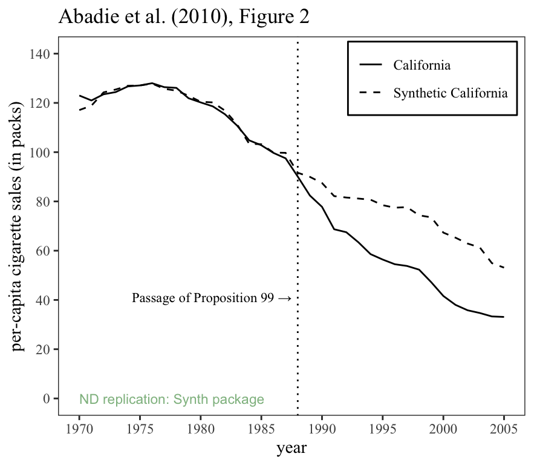

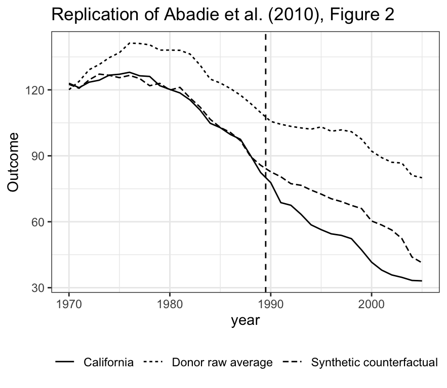

```r
p <- plot(syn_rstat, plot_type = 'outcomes raw average') +
    ggtitle("Replication of Abadie et al. (2010), Figure 2")
```

To get Table 1, the comparison of the means of various covariates, we can use

```r
covariate_balance_table( syn, pre_period = c( 1975, 1980, 1988 ) ) %>%
    knitr::kable( digits = 2 )
```

| variable | Tx | Co | Raw |
| --- | --- | --- | --- |
| retail | 89.42 | 90.40 | 87.27 |
| xxincome | 10.03 | 9.97 | 9.79 |
| K1_r_15_24 | 17.87 | 17.88 | 17.83 |
| beer | 24.28 | 23.25 | 23.66 |
| 1975 | 127.10 | 121.48 | 136.93 |
| 1980 | 120.20 | 123.65 | 138.09 |
| 1988 | 90.10 | 96.35 | 113.82 |

For Figure 3, we compare the estimated impact to that calculated in the original paper:

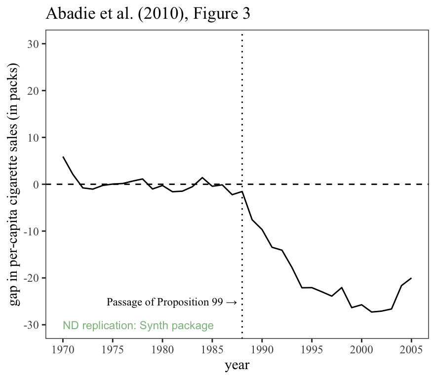

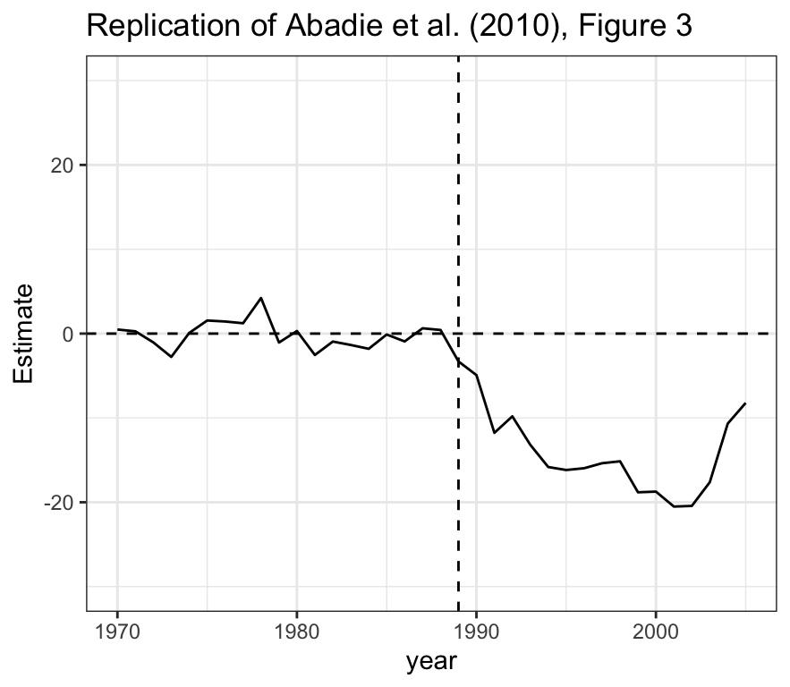

```r
p <- plot(syn_rstat, plot_type = 'estimate only') +
    ggtitle("Replication of Abadie et al. (2010), Figure 3") +
    scale_y_continuous(limits = c(-30, 30))
```

We see a bit more choppyness than the Synth package.

We can finally plot our result, using `plot_type = "placebo"`, to obtain a plot showing each placebo trajectory:

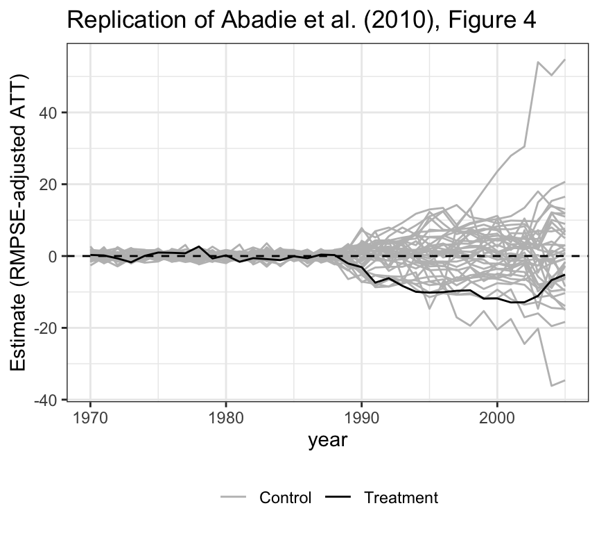

```r
plot(syn_rstat, plot_type = 'placebo' ) +
    ggtitle("Replication of Abadie et al. (2010), Figure 4")
```

We can get the raw trajectories via

```r
placebo_distribution( syn_rstat )
```

```
#> # A tibble: 1,404 × 8
#>    state     trt  year  Yhat  Yobs     ATT RMSPE   rstat
#>    <chr>   <dbl> <dbl> <dbl> <dbl>   <dbl> <dbl>   <dbl>
#>  1 Alabama     0  1970  91.5  89.8 -1.67    1.14 -1.47
#>  2 Alabama     0  1971  96.5  95.4 -1.06    1.14 -0.926
#>  3 Alabama     0  1972 100.  101.   1.08    1.14  0.941
#>  4 Alabama     0  1973 104.  103.  -1.15    1.14 -1.00
#>  5 Alabama     0  1974 108.  108.   0.0232  1.14  0.0203
#>  6 Alabama     0  1975 112.  112.  -0.269   1.14 -0.236
#>  7 Alabama     0  1976 115.  116.   1.10    1.14  0.964
#>  8 Alabama     0  1977 117.  117.  -0.149   1.14 -0.130
#>  9 Alabama     0  1978 120.  123    2.62    1.14  2.29
#> 10 Alabama     0  1979 120.  121.   1.38    1.14  1.21
#> # ℹ 1,394 more rows
```

To see what makes up our synthetic unit, we can use `donor_table()` to obtain a dataframe with the RMSPE and synthetic weight for each of the donor units.

```r
donor_table(syn_rstat) %>%
    arrange( -abs(weight) )
```

```
#> # A tibble: 38 × 3
#>    state        weight RMSPE
#>    <chr>         <dbl> <dbl>
#>  1 Colorado     0.545   2.68
#>  2 Connecticut  0.363   2.69
#>  3 Utah         0.106   2.70
#>  4 Nevada       0.0935  5.11
#>  5 Mississippi -0.0792  1.66
#>  6 Arkansas    -0.0689  1.73
#>  7 Virginia     0.0560  1.95
#>  8 New Mexico   0.0522  1.43
#>  9 Oklahoma    -0.0480  2.27
#> 10 Tennessee   -0.0445  1.46
#> # ℹ 28 more rows
```

California is apparently mainly a mix of Colorado and Connecticut, with a bit of Utah and Nevada thrown in. The negative weights, and the lack of sparse weights, are from the ridge regresssion. Without that second stage, these weights would generally be sparse, as in the original paper. For example:

```r
syn_classic <- augsynth(form = cigsalepcap ~ treated | retail + xxincome + K1_r_15_24 + beer,
                unit = state,
                time = year,
                data = tobacco_70,
                progfunc = "none" )
donor_table(syn_classic) %>%
    filter( weight!= 0 ) %>%
    arrange( -abs(weight) )
```

```
#> # A tibble: 5 × 3
#>   state       weight RMSPE
#>   <chr>        <dbl> <dbl>
#> 1 Colorado    0.564   4.62
#> 2 Connecticut 0.342   5.30
#> 3 Utah        0.0508 24.4
#> 4 New Mexico  0.0274  3.58
#> 5 Nevada      0.0156  9.17
```

### Sensitivity checks by limiting the donor pool

The augsynth models can be re-fitted after excluding certain donor units via the `update_augsynth()` method. The main method is to set `drop` to a multiplier for the treatment unit RMSPE. All units with a RMSPE larger than that value will be dropped:

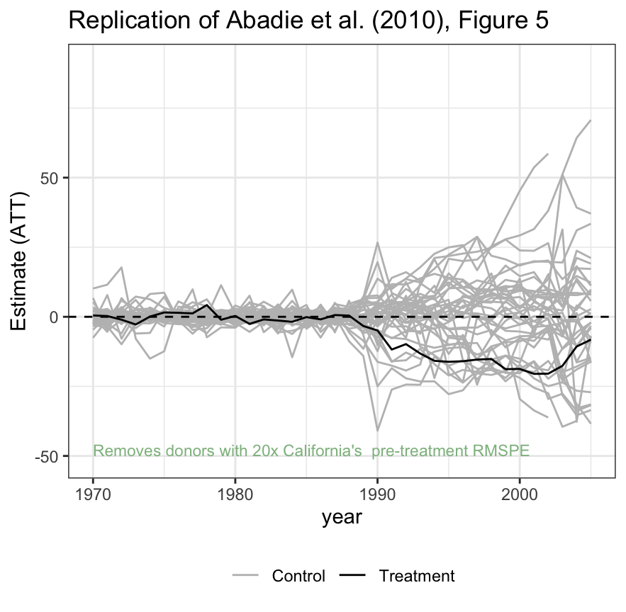

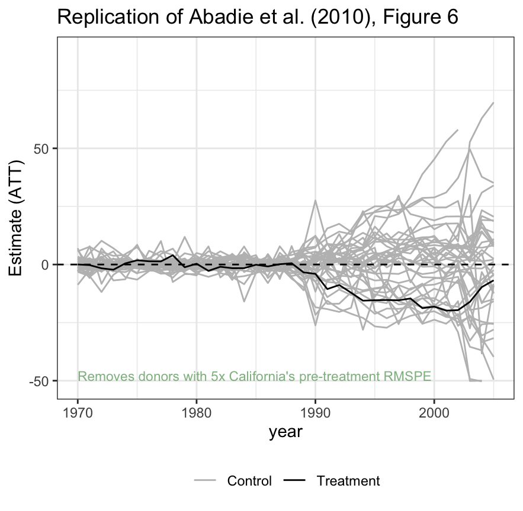

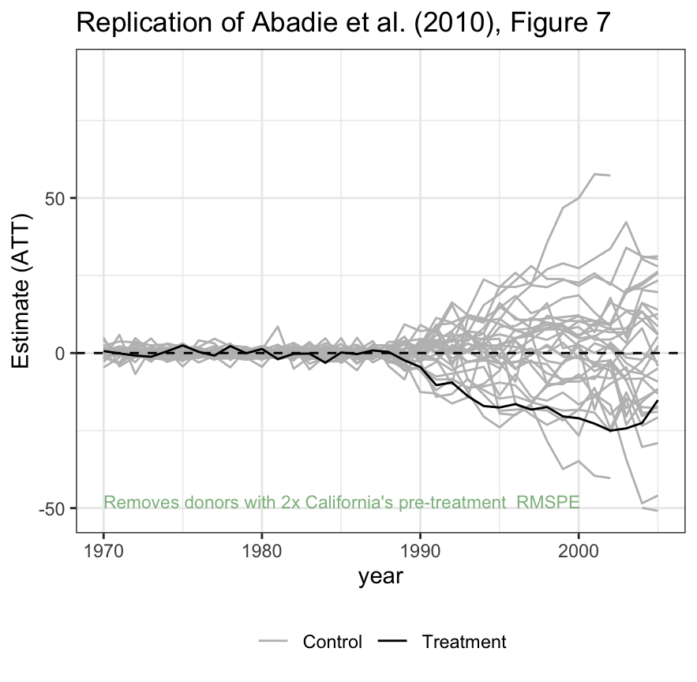

```r
update_augsynth(syn) %>% # drops units with >20x treated RMSPE by default
    summary( inf_type = 'permutation' ) %>%
    plot(plot_type = 'placebo' ) +
    ggtitle("Replication of Abadie et al. (2010), Figure 5") + ylim(-51, 91) +
    annotate('text', y = -48, x = 1970,
             label = "Removes donors with 20x California's  pre-treatment RMSPE",
             hjust = 0, color = 'darkseagreen', size = 3)
update_augsynth(syn, drop = 5) %>%
    summary( inf_type = 'permutation' ) %>%
    plot(plot_type = 'placebo') +
    ggtitle("Replication of Abadie et al. (2010), Figure 6") + ylim(-51, 91) +
    annotate('text', y = -48, x = 1970,
             label = "Removes donors with 5x California's pre-treatment RMSPE",
             hjust = 0, color = 'darkseagreen', size = 3)
update_augsynth(syn, drop = 2) %>%
    summary( inf_type = 'permutation' ) %>%
    plot(plot_type = 'placebo') +
    ggtitle("Replication of Abadie et al. (2010), Figure 7") + ylim(-51, 91) +
    annotate('text', y = -48, x = 1970,
             label = "Removes donors with 2x California's pre-treatment  RMSPE",
             hjust = 0, color = 'darkseagreen', size = 3)
```

Alternatively, the names of units to be excluded can be passed in directly as characters using `drop`.

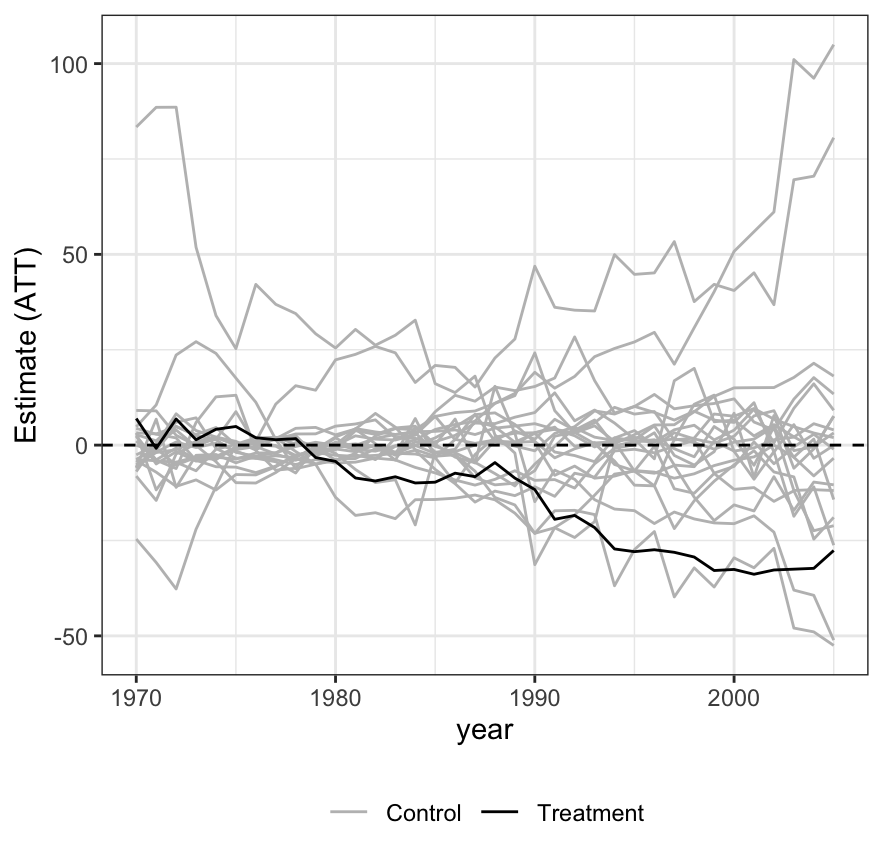

```r
drop_states <- c("Iowa", "Arizona", "Alabama", "Illinois", "Indiana", "Idaho", "Connecticut",
                 "New Mexico", "Texas", "Utah", "North Dakota", "South Dakota", "Vermont",
                 "Wisconsin", "West Virginia", "Wyoming", "Tennessee", "Pennsylvania")

update_augsynth(syn, drop = drop_states) %>%
    summary( inf_type = 'permutation' ) %>%
    plot(plot_type = 'placebo')
```